# Charity Project - Part 2

### 1. Read data from csv file

1. Here I use the na.strings=“NA” argument to encode the missing values.
2. I set stringsAsFactors=TRUE
3. Finally, I use the colClasses argument to update DONR, HOME, and HINC from integers to factors. Note that the additional colClasses option was added because DONR, HOME, and HINC were not automatically set to factors. For the purpose of this analysis it is necessary for these variables to be factors.

```r
setwd('/Users/stevenfutter/Dropbox/NU/MACHINE_LEARNING/charity_project/part2')
charity = read.csv('projectDataPart2.csv', header=T, na.strings=c("NA"," "),stringsAsFactors = TRUE,
                   colClasses=c("DONR"="factor", "HOME"="factor","HINC"="factor"))

# set up $ expansion
attach(charity)

# check that column types are set up correctly
str(charity)
```

```
## 'data.frame':    71700 obs. of  21 variables:
##  $ ID      : int  1 3 4 6 8 12 14 15 16 17 ...
##  $ DONR    : Factor w/ 2 levels "0","1": 1 1 1 1 1 1 1 1 1 1 ...
##  $ DAMT    : num  0 0 0 0 0 0 0 0 0 0 ...
##  $ AGE     : int  62 86 66 52 55 49 41 48 58 75 ...
##  $ HOME    : Factor w/ 2 levels "0","1": 2 1 2 2 2 1 1 1 2 2 ...
##  $ HINC    : Factor w/ 7 levels "1","2","3","4",..: 4 NA 6 4 2 NA NA 5 6 7 ...
##  $ GENDER  : Factor w/ 6 levels "A","C","F","J",..: 5 3 5 4 3 5 3 3 3 3 ...
##  $ MEDAGE  : int  45 38 44 32 42 39 40 43 47 49 ...
##  $ MEDPPH  : int  180 118 225 247 208 266 288 198 236 183 ...
##  $ MEDHVAL : int  313 1131 1518 857 440 580 678 1044 871 5913 ...
##  $ MEDINC  : int  195 323 728 501 236 202 171 562 322 810 ...
##  $ MEDEDUC : int  120 160 160 140 120 120 114 120 120 160 ...
##  $ NUMPROM : int  34 53 18 43 55 23 14 24 56 32 ...
##  $ NUMPRM12: int  14 13 13 14 12 11 8 12 13 12 ...
##  $ RAMNTALL: num  53 68 20 84 172 35 15 39 115 44 ...
##  $ NGIFTALL: int  6 8 2 7 16 3 1 5 6 5 ...
##  $ MAXRAMNT: num  12 15 15 15 15 20 15 10 25 12 ...
##  $ LASTGIFT: num  10 15 15 10 11 20 15 7 25 12 ...
##  $ TDON    : num  16 17 18 16 22 ...
##  $ RFA_97  : Factor w/ 14 levels "L1E","L1F","L1G",..: 12 5 5 13 4 5 2 8 3 8 ...
##  $ RFA_96  : Factor w/ 69 levels "A1D","A1E","A1F",..: 17 8 43 18 56 2 23 12 4 12 ...
```

```r
# confirm size of data table
dim(charity) # 71700 21 in part 2 csv compared to part 1 csv which was dim: 3684 21
```

```
## [1] 71700    21
```

```r
# take a peek at the data
head(charity)
```

```
##   ID DONR DAMT AGE HOME HINC GENDER MEDAGE MEDPPH MEDHVAL MEDINC MEDEDUC
## 1  1    0    0  62    1    4      M     45    180     313    195     120
## 2  3    0    0  86    0 <NA>      F     38    118    1131    323     160
## 3  4    0    0  66    1    6      M     44    225    1518    728     160
## 4  6    0    0  52    1    4      J     32    247     857    501     140
## 5  8    0    0  55    1    2      F     42    208     440    236     120
## 6 12    0    0  49    0 <NA>      M     39    266     580    202     120
##   NUMPROM NUMPRM12 RAMNTALL NGIFTALL MAXRAMNT LASTGIFT TDON RFA_97 RFA_96
## 1      34       14       53        6       12       10   16    L4E    A4E
## 2      53       13       68        8       15       15   17    L2F    A2F
## 3      18       13       20        2       15       15   18    L2F    N2F
## 4      43       14       84        7       15       10   16    L4F    A4F
## 5      55       12      172       16       15       11   22    L2E    S2E
## 6      23       11       35        3       20       20   15    L2F    A1E
```

### 2. Data Quality Check

1. We now look at a quick summary of the values of the data to get a feel for the value ranges, shape of the distributions, and the number of missing values for each variable in the dataset. To do this we use R’s Hmisc library to describe the dataset, as below.

As can be seen in the output MEDHVAL and RAMNTALL appear to be highly skewed since the mean and median numbers are quite different. Other variables have extreme high and low values. For example, RAMNTALL, the dollar amount of lifetime gifts to date, has 276 as the 95% percentile value, but the highest values are 3212, 3775, 3985, 3986, 5674.90. Other variables are similar to RAMNTALL, but this is better highlighted by the matrix of histograms. See part (c) below.

```r
library(Hmisc)
Hmisc::describe(charity)
```

```
## charity
##
##  21  Variables      71700  Observations
## ---------------------------------------------------------------------------
## ID
##        n  missing distinct     Info     Mean      Gmd      .05      .10
##    71700        0    71700        1    95741    63967     9528    19089
##      .25      .50      .75      .90      .95
##    47764    95691   143644   172521   182157
##
## lowest :      1      3      4      6      8
## highest: 191767 191770 191773 191776 191777
## ---------------------------------------------------------------------------
## DONR
##        n  missing distinct
##    71700        0        2
##
## 0 (68016, 0.949), 1 (3684, 0.051)
## ---------------------------------------------------------------------------
## DAMT
##        n  missing distinct     Info     Mean      Gmd      .05      .10
##    71700        0       66    0.146   0.8075     1.56        0        0
##      .25      .50      .75      .90      .95
##        0        0        0        0        4
##
## lowest :   0.0   1.0   2.0   2.5   3.0
## highest:  75.0 100.0 102.0 150.0 200.0
## ---------------------------------------------------------------------------
## AGE
##        n  missing distinct     Info     Mean      Gmd      .05      .10
##    71700        0       79        1    61.65    19.11       35       39
##      .25      .50      .75      .90      .95
##       48       62       75       83       87
##
## lowest : 20 21 22 23 24, highest: 94 95 96 97 98
## ---------------------------------------------------------------------------
## HOME
##        n  missing distinct
##    71700        0        2
##
```

[output cut: 124 more lines]

```
##
## Value        L1E   L1F   L1G   L2E   L2F   L2G   L3D   L3E   L3F   L3G
## Frequency   3926 22718  9326  3997  8255  3458  1910  5697  2676  1147
## Proportion 0.055 0.317 0.130 0.056 0.115 0.048 0.027 0.079 0.037 0.016
##
## Value        L4D   L4E   L4F   L4G
## Frequency   3562  2868  1495   665
## Proportion 0.050 0.040 0.021 0.009
## ---------------------------------------------------------------------------
## RFA_96
##        n  missing distinct
##    70871      829       69
##
## lowest : A1D A1E A1F A1G A2C, highest: S4C S4D S4E S4F S4G
## ---------------------------------------------------------------------------
```

HINC : 8301 GENDER : 1198 RFA_96 : 829

```r
sapply(charity, function(x) sum(is.na(x)))
```

```
##       ID     DONR     DAMT      AGE     HOME     HINC   GENDER   MEDAGE
##        0        0        0        0        0     8301     1198        0
##   MEDPPH  MEDHVAL   MEDINC  MEDEDUC  NUMPROM NUMPRM12 RAMNTALL NGIFTALL
##        0        0        0        0        0        0        0        0
## MAXRAMNT LASTGIFT     TDON   RFA_97   RFA_96
##        0        0        0        0      829
```

3. As mentioned in part (a), besides the missing values it appears that many of the variables in the data set are either positively or negatively skewed. This is best represented by a matrix of histograms, as below. The skewness or non-normality in some of the variables of the dataset may cause issues for some type of model fits which rely upon normality in the residuals. In addition, many of the variables have extreme values. In particular, the following variables have long tails to the right: MEDHVAL, MEDINC, NUMPRM12, RAMNTALL, NGIFTALL, MAXRAMNT, and LASTGIFT. MEDEDUC and TDON have long tails to the left.

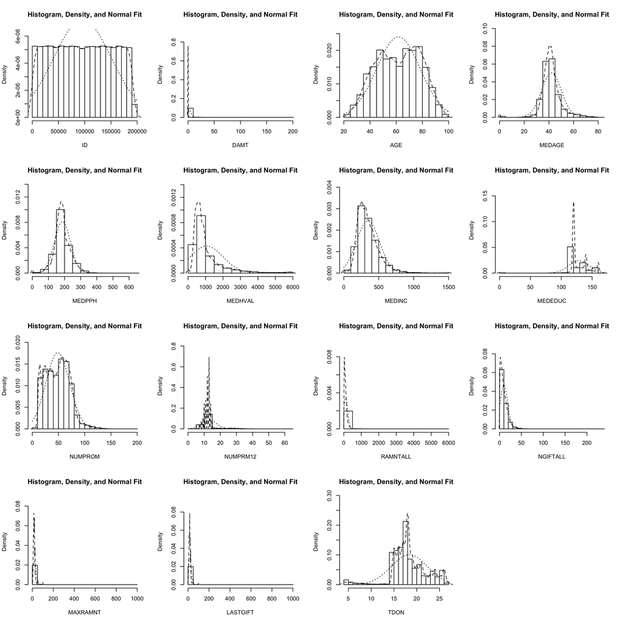

```r
library(plyr)
library(psych)
multi.hist(charity[,sapply(charity, is.numeric)])
```

### 3. Exploratory Data Analysis (EDA)

We now carry out some exploratory data analysis to look for interesting relationships in the data.

1. First, we use R to perform EDA for the dataset provided. The response for the regression problem is DAMT. Note that ID is for identification purposes only and is not to be used as a predictor. We remove ID here:

```r
df = charity[,-1]   # remove ID variable
names(df)
```

```
##  [1] "DONR"     "DAMT"     "AGE"      "HOME"     "HINC"     "GENDER"
##  [7] "MEDAGE"   "MEDPPH"   "MEDHVAL"  "MEDINC"   "MEDEDUC"  "NUMPROM"
## [13] "NUMPRM12" "RAMNTALL" "NGIFTALL" "MAXRAMNT" "LASTGIFT" "TDON"
## [19] "RFA_97"   "RFA_96"
```

```r
#pairs(charity[,sapply(charity, is.numeric)], col=df1$DONR)
```

2. Let’s now review some boxplots and mosaic charts to help us determine which of the predictors show the most promise for predicting whether or not an individual will donate.

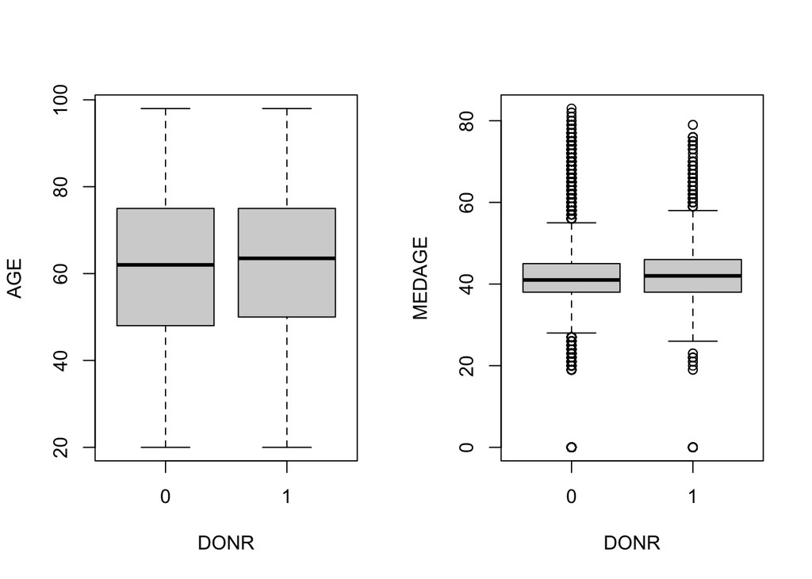

```r
# Use the numeric fields to draw boxplots
par(mfrow=c(1,2))
boxplot(AGE~DONR, data=charity, col='lightgray',xlab="DONR", ylab="AGE")           #nothing of interest.
boxplot(MEDAGE~DONR, data=charity, col='lightgray',xlab="DONR", ylab="MEDAGE")     #nothing of interest.
```

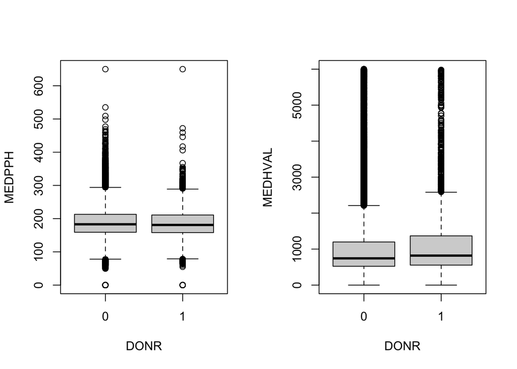

```r
par(mfrow=c(1,2))
boxplot(MEDPPH~DONR, data=charity, col='lightgray',xlab="DONR", ylab="MEDPPH")     #nothing of interest.
boxplot(MEDHVAL~DONR, data=charity, col='lightgray',xlab="DONR", ylab="MEDHVAL")   #nothing of interest.
```

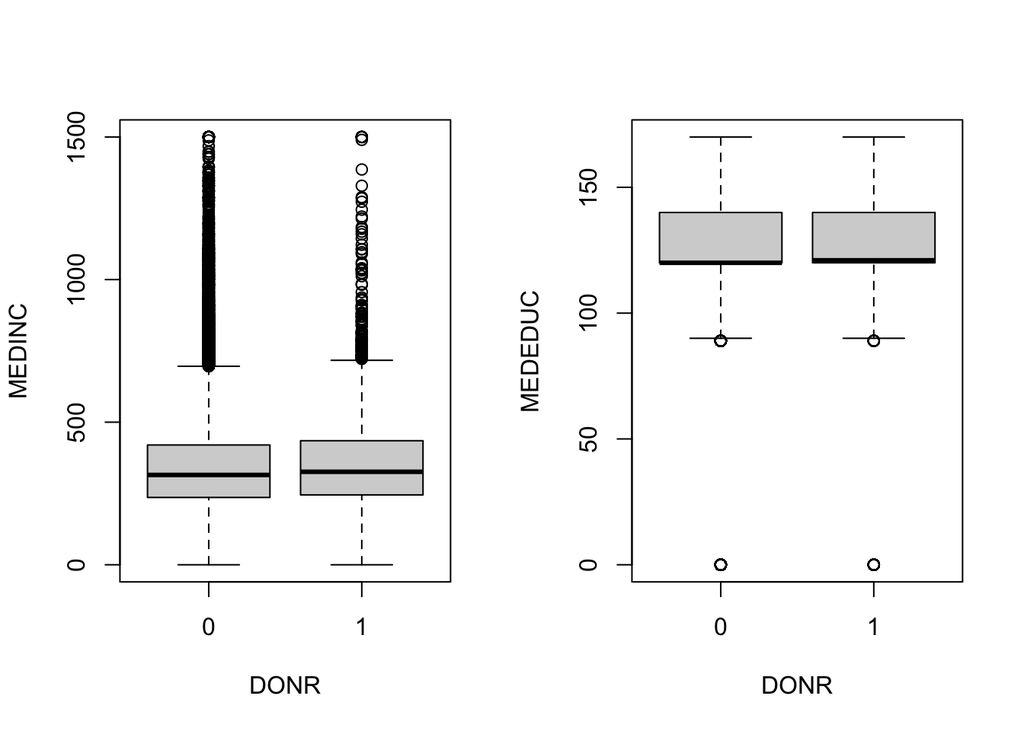

```r
par(mfrow=c(1,2))
boxplot(MEDINC~DONR, data=charity, col='lightgray',xlab="DONR", ylab="MEDINC")     #nothing of interest.
boxplot(MEDEDUC~DONR, data=charity, col='lightgray',xlab="DONR", ylab="MEDEDUC")   #nothing of interest.
```

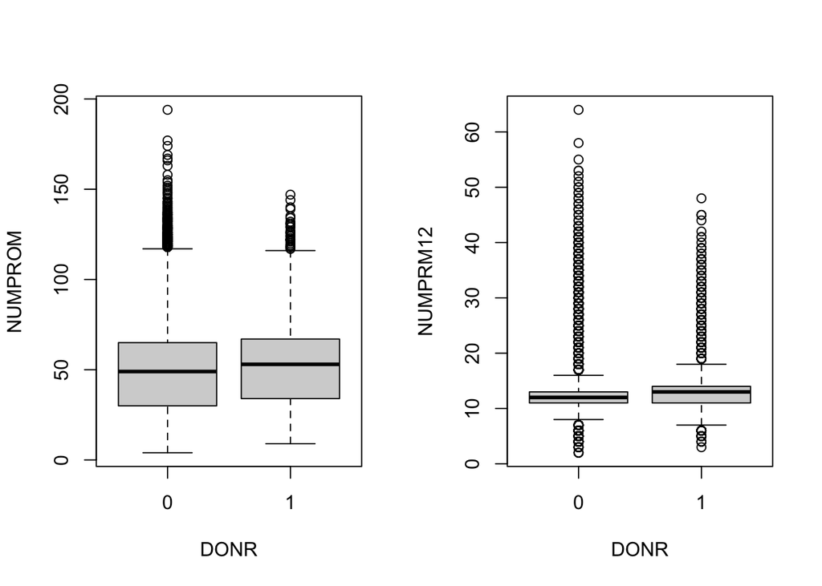

```r
par(mfrow=c(1,2))
boxplot(NUMPROM~DONR, data=charity, col='lightgray',xlab="DONR", ylab="NUMPROM")   #nothing of interest.
boxplot(NUMPRM12~DONR, data=charity, col='lightgray',xlab="DONR", ylab="NUMPRM12") #nothing of interest.
```

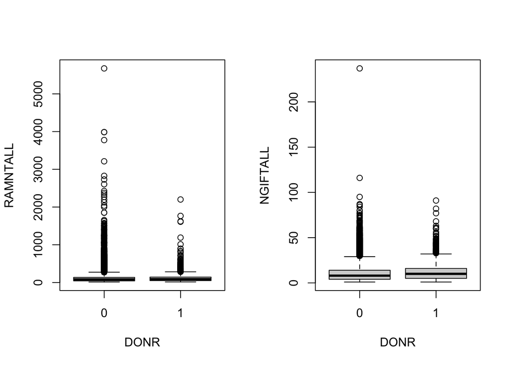

```r
par(mfrow=c(1,2))
boxplot(RAMNTALL~DONR, data=charity, col='lightgray',xlab="DONR", ylab="RAMNTALL") #nothing of interest.
boxplot(NGIFTALL~DONR, data=charity, col='lightgray',xlab="DONR", ylab="NGIFTALL") #nothing of interest.
```

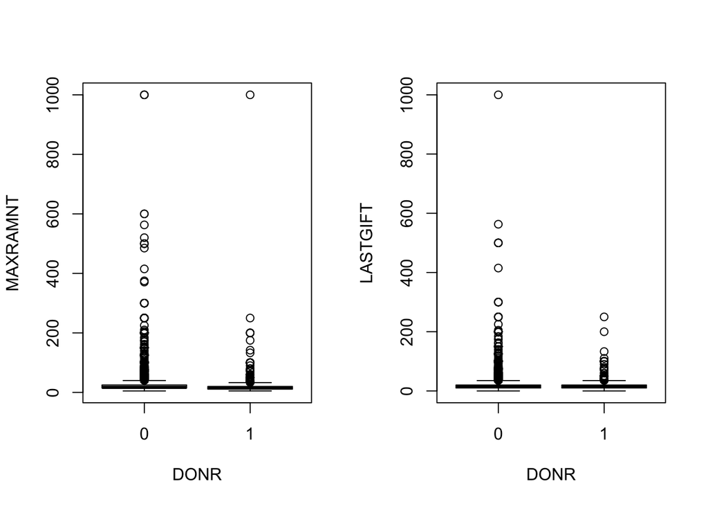

```r
par(mfrow=c(1,2))
boxplot(MAXRAMNT~DONR, data=charity, col='lightgray',xlab="DONR", ylab="MAXRAMNT") #nothing of interest.
boxplot(LASTGIFT~DONR, data=charity, col='lightgray',xlab="DONR", ylab="LASTGIFT") #nothing of interest.
```